# deca_decontam.Rmd

Dylan Barth

2025-12-12

## Decontam and Filtering

In this script, we test for contamination found in our negative control sample. We then remove any ASVs identified as contamination. We also remove all samples with libraries below a threshold of 2500 reads. This cleans the data and prepares it for downstream analysis.

#### Import data

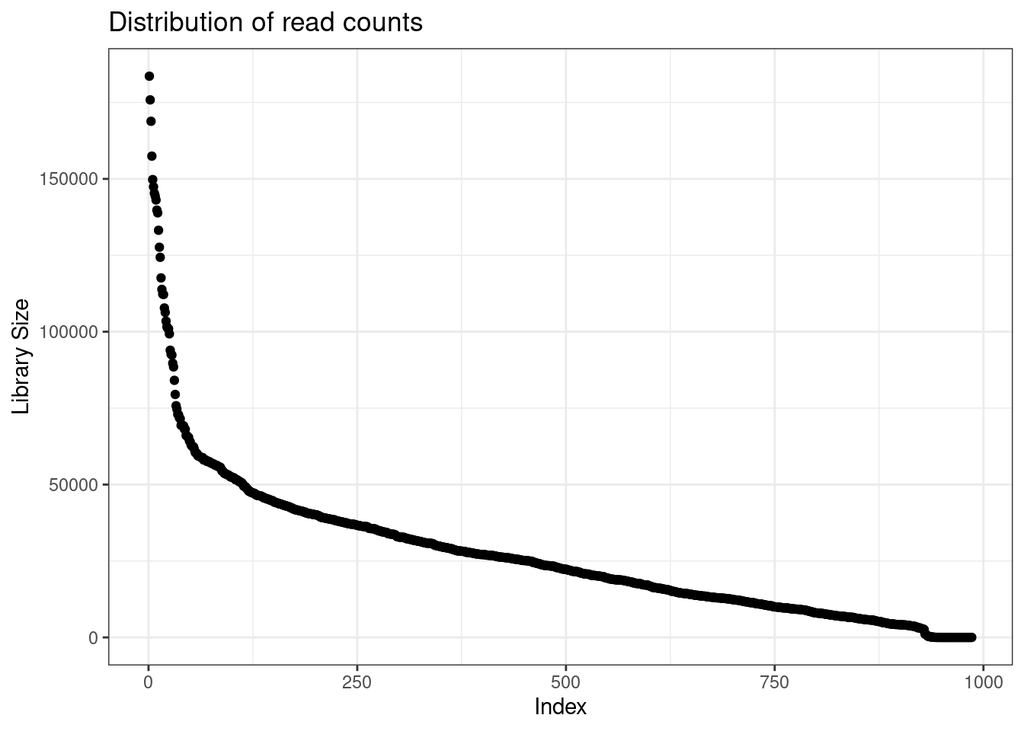

```r
ps <- readRDS('data/16Sdada2/phyloseq_dada2.rds')
meta <- data.frame(sample_data(ps))

##check the distribution of library size
gdat <- tibble(ncounts=sample_sums(ps), SampleID=sample_names(ps))
gdat <- left_join(meta, gdat, by='SampleID')
gdat <- gdat %>% arrange(-ncounts) %>% mutate(index=row_number())
ggplot(gdat)+
  geom_point(aes(x=index, y=ncounts))+
  theme_bw()+
  xlab("Index")+
  ylab("Library Size")+
  ggtitle("Distribution of read counts")
```

#### Run decontam

Here we run the decontam library pipeline to identify contamination in our samples as determined by presence in our negative control sample. These ASV are then dropped from the analysis.

```r
##check which is a neg control
sample_data(ps)[which(grepl('Neg', sample_data(ps)$Microhabitat)),]
```

```
##                                   R1                           R2  SampleDate
## C6_S161 C6_S161_L001_R1_001.fastq.gz C6_S161_L001_R2_001.fastq.gz Neg_Control
##              PlotNr Microhabitat Surface_Subsurface Grass_Interspace Notes
## C6_S161 Neg_Control  Neg_Control        Neg_Control      Neg_Control  <NA>
##           Treatment ...10 ...11 SampleID
## C6_S161 Neg_Control    NA    NA  C6_S161
```

```r
sample_data(ps)$is.neg <- sample_data(ps)$Microhabitat=='Neg_Control'

##run decontam
decdf <- isContaminant(ps, method='prevalence', neg='is.neg')
cindx <- which(decdf$contaminant)

##check abundances
tdat <- as.data.frame(otu_table(ps))[,cindx]
tdat[which(tdat>0)]
```

```
## [1]   3  11 502 498
```

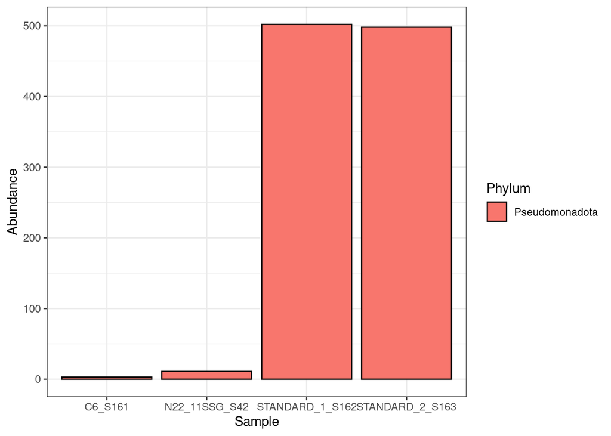

```r
##plot abundance
tmp <- prune_taxa(paste('ASV', cindx, sep=''), ps)
tmp <- subset_samples(tmp, sample_sums(tmp)>0)
plot_bar(tmp, x='Sample',fill='Phylum') + theme_bw()
```

```r
##remove taxa
comp_tax <- setdiff(taxa_names(ps), paste('ASV', cindx, sep=''))
ps <- prune_taxa(comp_tax, ps)
```

#### Filter low library sizes

Here we filter out sample libraries with less than 2500 reads. Note the gap separating extremely low abundance libraries and the rest of the data. We also need to remove any taxa that were unique to those samples. The process is finished by saving this pruned data to a new file, keeping the old phyloseq object in tact for rare-species analysis.

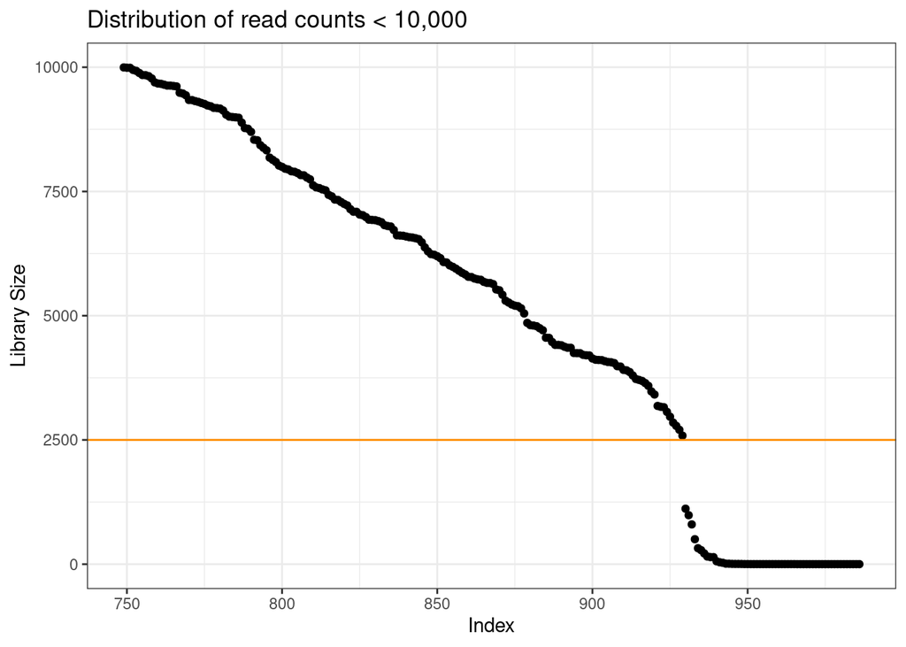

```r
##check low abundance distribution
thresh <- 2500
ggplot(gdat %>% filter(ncounts<10000))+
  geom_point(aes(x=index, y=ncounts))+
  geom_hline(aes(yintercept=thresh), color='darkorange')+
  theme_bw()+
  xlab("Index")+
  ylab("Library Size")+
  ggtitle("Distribution of read counts < 10,000")
```

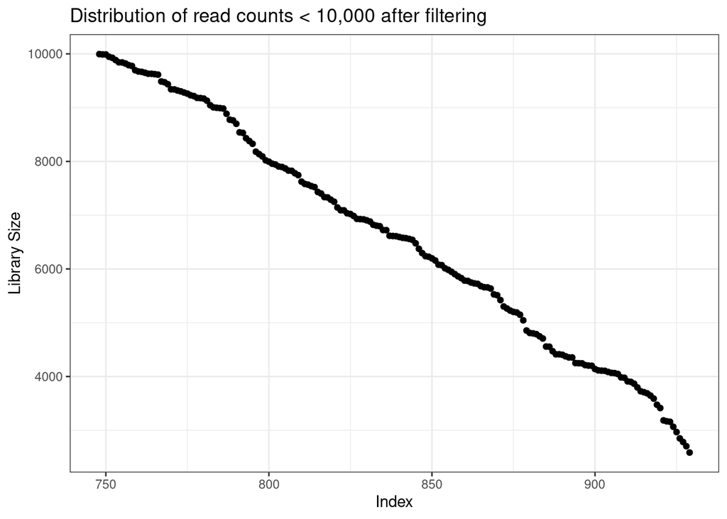

```r
#filter samples
ps.filt <- subset_samples(ps, sample_sums(ps) > thresh)
ps.filt <- prune_taxa( taxa_sums(ps.filt) > 0, ps.filt)

gdat <- tibble(ncounts=sample_sums(ps.filt), SampleID=sample_names(ps.filt))
gdat <- left_join(meta, gdat, by='SampleID')
gdat <- gdat %>% arrange(-ncounts) %>% mutate(index=row_number())
ggplot(gdat %>% filter(ncounts<10000))+
  geom_point(aes(x=index, y=ncounts))+
  theme_bw()+
  xlab("Index")+
  ylab("Library Size")+
  ggtitle("Distribution of read counts < 10,000 after filtering")
```

## Remove Control Samples

We also don’t want any of the control samples in our downstream analyses, so we prune them out as well.

```r
rem <- sample_names(ps.filt)[grepl('STANDARD|C6',sample_names(ps.filt))]
ps.filt <- prune_samples(!(sample_names(ps.filt) %in% rem), ps.filt)

##save
saveRDS(ps.filt, file='data/16Sdada2/phyloseq.filtered.rds')
```